# PredictionAssignment

# Overview

In this report, we are using the Weight Lifting Exercise Dataset to predict the manner in which they did the exercise. We will use data from accelerometers on the belt, forearm, arm, and dumbell of 6 participants who were asked to perform barbell lifts correctly and incorrectly in 5 different ways.

Note: The dataset used in this project is a courtesy of “Ugulino, W.; Cardador, D.; Vega, K.; Velloso, E.; Milidiu, R.; Fuks, H. Wearable Computing: Accelerometers’ Data Classification of Body Postures and Movements”

# Data Processing

Load libraries:

```r
library(caret)
library(corrplot)
library(rpart)
library(rpart.plot)
library(rattle)
library(randomForest)
```

Download data from source:

```r
# create "data" folder if it doesn't already exist
if(!dir.exists("./data"))
    dir.create("./data")

# download files if it doesn't already exist
if(!file.exists("./data/pml-training.csv")) {
    download.file("https://d396qusza40orc.cloudfront.net/predmachlearn/pml-training.csv"
                  , "./data/pml-training.csv", mode="wb")
}

if(!file.exists("./data/pml-testing.csv")) {
    download.file("https://d396qusza40orc.cloudfront.net/predmachlearn/pml-testing.csv"
                  , "./data/pml-testing.csv", mode="wb")
}
```

### Reading dataset:

```r
traintest <- read.csv("./data/pml-training.csv")
validateset  <- read.csv("./data/pml-testing.csv")
```

The traintest dataset will be split into 2:

- a training set for modeling (70%)
- a testing set for validation (30%)

The validateset dataset will only be used for prediction quiz.

### Cleaning up dataset:

The dataset has many variables:

```r
dim(traintest)
```

```
## [1] 19622   160
```

Some of those are identification variables that are not relevant to the study (eg. subject names, timestamps), variables with mostly NAs values and variables with nearly zero variance(NZV) which will bring no value to the analysis.

Remove identification variables (columns 1 - 7):

```r
traintest <- traintest[, -(1:7)]
```

Remove variables with mostly NAs:

```r
traintest<- traintest[, colSums(is.na(traintest)) == 0]
```

Remove variables with nearly zero variance (NZV):

```r
nzv <- nearZeroVar(traintest)
traintest <- traintest[, -nzv]
```

After cleaning variables:

```r
dim(traintest)
```

```
## [1] 19622    53
```

### Splitting into training and testing dataset:

```r
inTrain  <- createDataPartition(traintest$classe, p=0.7, list=FALSE)
trainset <- traintest[inTrain, ]
testset  <- traintest[-inTrain, ]
```

Training set dimension:

```r
dim(trainset)
```

```
## [1] 13737    53
```

Testing set dimension:

```r
dim(testset)
```

```
## [1] 5885   53
```

# Data Analysis

### Correlation Analysis

Analyze variables’ correlation using corrplot:

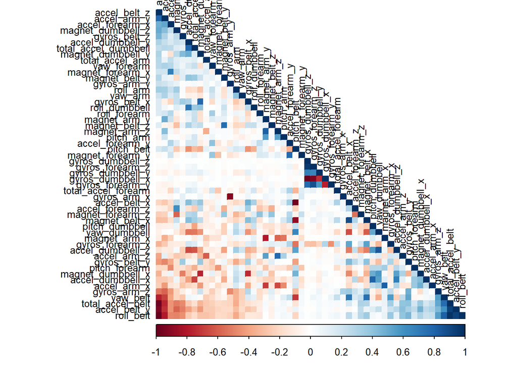

```r
corMatrix <- cor(trainset[, -53])
corrplot(corMatrix, order = "FPC", method = "color", type = "lower",
         tl.cex = 0.8, tl.col = rgb(0, 0, 0))
```

Highly correlated variables are shown in darker colours in the corrplot.

# Prediction Model Building

In this project, we will use 3 methods:

1. Classification tree
2. Random forest
3. Generalized boosted model

### Classification Tree

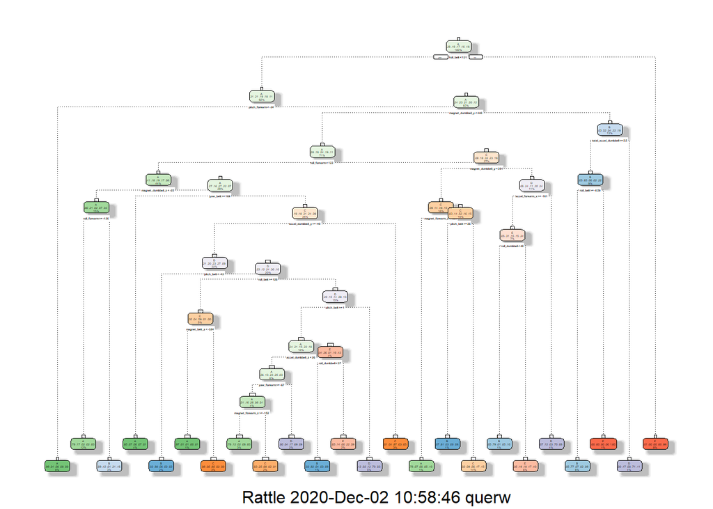

```r
set.seed(1234)
modfitTree <- rpart(classe ~ ., data=trainset, method="class")
fancyRpartPlot(modfitTree)
```

Validate using testset:

```r
predictTree <- predict(modfitTree, newdata=testset, type="class")
cmTree <- confusionMatrix(predictTree, as.factor(testset$classe))
cmTree
```

```
## Confusion Matrix and Statistics
##
##           Reference
## Prediction    A    B    C    D    E
##          A 1475  166   22   52   16
##          B   66  690   51   92   82
##          C   51  111  806  141  118
##          D   58   78   68  603   61
##          E   24   94   79   76  805
##
## Overall Statistics
##
##                Accuracy : 0.7441
##                  95% CI : (0.7327, 0.7552)
##     No Information Rate : 0.2845
##     P-Value [Acc > NIR] : < 2.2e-16
##
##                   Kappa : 0.676
##
##  Mcnemar's Test P-Value : < 2.2e-16
##
## Statistics by Class:
##
##                      Class: A Class: B Class: C Class: D Class: E
## Sensitivity            0.8811   0.6058   0.7856   0.6255   0.7440
## Specificity            0.9392   0.9387   0.9134   0.9461   0.9432
## Pos Pred Value         0.8521   0.7034   0.6569   0.6947   0.7468
## Neg Pred Value         0.9521   0.9084   0.9528   0.9280   0.9424
## Prevalence             0.2845   0.1935   0.1743   0.1638   0.1839
## Detection Rate         0.2506   0.1172   0.1370   0.1025   0.1368
## Detection Prevalence   0.2941   0.1667   0.2085   0.1475   0.1832
## Balanced Accuracy      0.9102   0.7722   0.8495   0.7858   0.8436
```

**Decision tree accuracy: 0.7440952**

### Random Forest

```r
controlRF <- trainControl(method="cv", number=3, verboseIter=FALSE)
modfitRF <- train(classe ~ ., data=trainset, method="rf", trControl=controlRF)
modfitRF$finalModel
```

```
##
## Call:
##  randomForest(x = x, y = y, mtry = param$mtry)
##                Type of random forest: classification
##                      Number of trees: 500
## No. of variables tried at each split: 27
##
##         OOB estimate of  error rate: 0.76%
## Confusion matrix:
##      A    B    C    D    E class.error
## A 3900    4    1    0    1 0.001536098
## B   25 2624    8    1    0 0.012791573
## C    0   14 2373    9    0 0.009599332
## D    0    0   28 2222    2 0.013321492
## E    0    1    5    6 2513 0.004752475
```

Validate using testset:

```r
predictRF <- predict(modfitRF, newdata=testset)
cmRF <- confusionMatrix(predictRF, as.factor(testset$classe))
cmRF
```

```
## Confusion Matrix and Statistics
##
##           Reference
## Prediction    A    B    C    D    E
##          A 1673    7    0    0    0
##          B    1 1131    4    1    0
##          C    0    1 1017   12    2
##          D    0    0    5  950    3
##          E    0    0    0    1 1077
##
## Overall Statistics
##
##                Accuracy : 0.9937
##                  95% CI : (0.9913, 0.9956)
##     No Information Rate : 0.2845
##     P-Value [Acc > NIR] : < 2.2e-16
##
##                   Kappa : 0.992
##
##  Mcnemar's Test P-Value : NA
##
## Statistics by Class:
##
##                      Class: A Class: B Class: C Class: D Class: E
## Sensitivity            0.9994   0.9930   0.9912   0.9855   0.9954
## Specificity            0.9983   0.9987   0.9969   0.9984   0.9998
## Pos Pred Value         0.9958   0.9947   0.9855   0.9916   0.9991
## Neg Pred Value         0.9998   0.9983   0.9981   0.9972   0.9990
## Prevalence             0.2845   0.1935   0.1743   0.1638   0.1839
## Detection Rate         0.2843   0.1922   0.1728   0.1614   0.1830
## Detection Prevalence   0.2855   0.1932   0.1754   0.1628   0.1832
## Balanced Accuracy      0.9989   0.9959   0.9941   0.9919   0.9976
```

**Random forest accuracy: 0.9937128**

### Generalized Boosted Model

```r
controlGBM <- trainControl(method="repeatedcv", number=5, repeats=1)
modfitGBM <- train(classe ~ ., data=trainset, method="gbm", trControl=controlGBM, verbose=FALSE)
modfitGBM$finalModel
```

```
## A gradient boosted model with multinomial loss function.
## 150 iterations were performed.
## There were 52 predictors of which 52 had non-zero influence.
```

```r
print(modfitGBM)
```

```
## Stochastic Gradient Boosting
##
## 13737 samples
##    52 predictor
##     5 classes: 'A', 'B', 'C', 'D', 'E'
##
## No pre-processing
## Resampling: Cross-Validated (5 fold, repeated 1 times)
## Summary of sample sizes: 10989, 10991, 10989, 10989, 10990
## Resampling results across tuning parameters:
##
##   interaction.depth  n.trees  Accuracy   Kappa
##   1                   50      0.7522018  0.6857894
##   1                  100      0.8217932  0.7744175
##   1                  150      0.8570993  0.8191793
##   2                   50      0.8576816  0.8196773
##   2                  100      0.9079844  0.8835492
##   2                  150      0.9309153  0.9125859
##   3                   50      0.8985935  0.8716276
##   3                  100      0.9421269  0.9267749
##   3                  150      0.9599618  0.9493476
##
## Tuning parameter 'shrinkage' was held constant at a value of 0.1
##
## Tuning parameter 'n.minobsinnode' was held constant at a value of 10
## Accuracy was used to select the optimal model using the largest value.
## The final values used for the model were n.trees = 150, interaction.depth =
##  3, shrinkage = 0.1 and n.minobsinnode = 10.
```

Validate using testset:

```r
predictGBM <- predict(modfitGBM, newdata=testset)
cmGBM <- confusionMatrix(predictGBM, as.factor(testset$classe))
cmGBM
```

```
## Confusion Matrix and Statistics
##
##           Reference
## Prediction    A    B    C    D    E
##          A 1655   42    0    0    5
##          B    9 1068   26    6   14
##          C    7   28  981   36    7
##          D    3    1   16  918   16
##          E    0    0    3    4 1040
##
## Overall Statistics
##
##                Accuracy : 0.9621
##                  95% CI : (0.9569, 0.9668)
##     No Information Rate : 0.2845
##     P-Value [Acc > NIR] : < 2.2e-16
##
##                   Kappa : 0.952
##
##  Mcnemar's Test P-Value : 3.564e-11
##
## Statistics by Class:
##
##                      Class: A Class: B Class: C Class: D Class: E
## Sensitivity            0.9886   0.9377   0.9561   0.9523   0.9612
## Specificity            0.9888   0.9884   0.9839   0.9927   0.9985
## Pos Pred Value         0.9724   0.9510   0.9263   0.9623   0.9933
## Neg Pred Value         0.9955   0.9851   0.9907   0.9907   0.9913
## Prevalence             0.2845   0.1935   0.1743   0.1638   0.1839
## Detection Rate         0.2812   0.1815   0.1667   0.1560   0.1767
## Detection Prevalence   0.2892   0.1908   0.1799   0.1621   0.1779
## Balanced Accuracy      0.9887   0.9630   0.9700   0.9725   0.9799
```

# Applying selected model to validation data

The accuracy of each model is as below:

| Model | Accuracy |
| --- | --- |
| Tree | 0.7440952 |
| Random Forest | 0.9937128 |
| Generalized Boosted Model | 0.9621071 |

Using Random Forest model on the validation data:

```r
predictValidate <- predict(modfitRF, newdata=validateset)
predictValidate
```

```
##  [1] B A B A A E D B A A B C B A E E A B B B
## Levels: A B C D E
```